# Milo: comparison to other methods

# Introduction

- Cluster-based: Louvain and Walktrap
- Cydar
- DA-seq

To compare methods I will calculate the ratio of cells that fall into true positive DA regions/clusters/neighbourhoods to false positive DA regions/clusters/neighbourhoods.

```r
### Set up a mock data set using simulated data
library(ggplot2)
library(igraph)
library(ggthemes)
library(ggsci)
library(umap)
library(reshape2)
library(SingleCellExperiment)
library(scran)
library(scater)
library(igraph)
library(miloR)
library(cowplot)
library(RColorBrewer)
library(pheatmap)
library(DAseq)
library(cydar)
```

I’ll use the simple linear trajectory data set for this with ~2000 cells and genuinely DA regions.

```r
n.dim <- 15
k <- 30
sim.data <- readRDS("~/Dropbox/Milo/simulations/data/Trajectory_Ncells2000_M3DA_simpleSim.RDS")
sim.mylo <- sim.data$mylo
sim.meta <- sim.data$meta
sim.mylo <- buildGraph(sim.mylo, k=k, d=n.dim, seed=42)
sim.mylo
```

```
class: Milo
dim: 2000 2000
metadata(0):
assays(2): counts logcounts
rownames(2000): G1 G2 ... G1999 G2000
rowData names(0):
colnames(2000): C1 C2 ... C1999 C2000
colData names(2): cell_id group_id
reducedDimNames(1): PCA
spikeNames(0):
altExpNames(0):
nhoods dimensions(1): 0
nhoodCounts dimensions(2): 1 1
nhoodDistances dimensions(2): 2000 2000
graph names(1): graph
nhoodIndex names(1): 0
nhoodExpression dimension(2): 1 1
nhoodReducedDim names(0):
```

I’ll create an embedding that can be used across all comparisons.

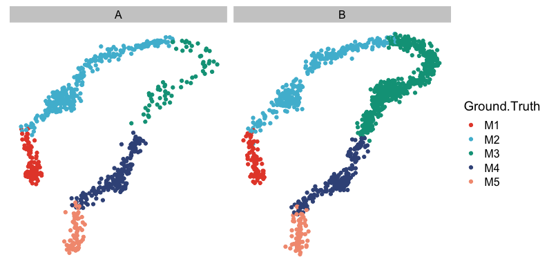

```r
set.seed(42)
sim.graph <- miloR::graph(sim.mylo)
sim.fr_layout <- layout_with_fr(sim.graph)
sim.fr.df <- as.data.frame(sim.fr_layout)
sim.fr.df$cell_id <- colnames(sim.mylo)
sim.fr.df <- merge(sim.fr.df, sim.meta, by='cell_id')
rownames(sim.fr.df) <- sim.fr.df$cell_id
ggplot(sim.fr.df, aes(x=V1, y=V2)) +
    geom_point(aes(colour=group_id)) +
    scale_colour_npg() +
    theme_cowplot() +
    theme(axis.line=element_blank(), axis.ticks=element_blank(),
          axis.text=element_blank(), axis.title=element_blank()) +
    guides(colour=guide_legend("Ground.Truth")) +
    facet_wrap(~Condition, nrow=1)
```

```r
ggsave("~/Dropbox/Milo/figures/MethodCompare_GroundTruth.png",
       height=4.15, width=8.25, dpi=300)
```

# Milo

```r
set.seed(42)
sim.mylo <- buildGraph(sim.mylo, k=k, d=n.dim, seed=42)
```

```
Constructing kNN graph with k:30
Retrieving distances from 30 nearest neighbours
```

```r
test.meta <- data.frame("Condition"=c(rep("A", 3), rep("B", 3)),
                        "Replicate"=rep(c("R1", "R2", "R3"), 2))
test.meta$Sample <- paste(test.meta$Condition, test.meta$Replicate, sep="_")
rownames(test.meta) <- test.meta$Sample
sim.mylo <- makeNhoods(sim.mylo, k=k, d=n.dim, prop=0.75, refined=TRUE)
```

```
Checking valid object
```

```r
sim.mylo <- miloR::countCells(sim.mylo, samples="Sample", meta.data=as.data.frame(sim.meta))
```

```
Checking meta.data validity
Setting up matrix with 344 neighbourhoods
Counting cells in neighbourhoods
```

```r
mylo.res <- testNhoods(sim.mylo, design=~Condition, design.df=test.meta[colnames(nhoodCounts(sim.mylo)), ])
```

```
Performing spatial FDR correction withk-distance weightingPerforming spatial FDR correction withneighbour-distance weightingPerforming spatial FDR correction withedge weightingPerforming spatial FDR correction withvertex weightingPerforming spatial FDR correction withnone weighting
```

```r
mylo.res$Diff <- sign(mylo.res$logFC)
mylo.res$Diff[mylo.res$SpatialFDR > 0.1] <- 0
table(mylo.res$Diff)
```

```
  0   1
224 120
```

# Cydar

`Cydar` requires the user to define a space in which to construct hyperspheres of a specific radius $r$. I will use the same number of PCs as was used to construct the kNN-graph with `Milo`; $r$ will have to be set by some other means.

```r
sim.list <- list()
for(x in seq_along(unique(sim.meta$Replicate))){
  plate <- unique(sim.meta$Replicate)[x]
  plate.red <- sim.meta[sim.meta$Replicate == plate, ]
  plate.ages <- unique(plate.red$Condition)
  for(i in seq_along(plate.ages)){
    age <- unique(plate.ages)[i]
    age.red <- reducedDim(sim.mylo)[sim.meta$Condition == age &
                                        sim.meta$Replicate %in% plate, ]

    age.mat <- as(age.red[, 1:n.dim], "matrix")
    sim.list[[paste(age, paste0(plate), sep=".")]] <- age.mat
  }
}
sim.cydar <- prepareCellData(sim.list)
```

The key paramater for `Cydar` is the radius of the hyperspheres - this can be selected heuristically by plotting the distribution of distances for increasing values of $r$.

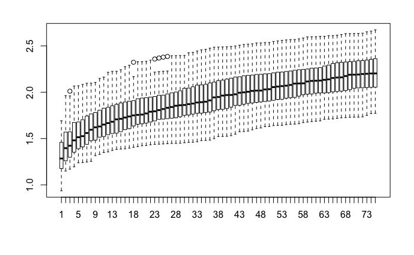

[output not shown]

`Cydar` finds 363 DA hyperspheres in this example.

# DAseq

```r
# k.vec <- c(5, 7, 10, 12, 15, 20, 25, 30, 35, 40, 45, 50)
k.vec <- c(50, 500, 50)
sim.daseq <- getDAcells(X=reducedDim(sim.mylo)[, 1:n.dim],
                        cell.labels=sim.meta$cell_id,
                        labels.1=sim.meta$cell_id[sim.meta$Condition %in% c("A")],
                        labels.2=sim.meta$cell_id[sim.meta$Condition %in% c("B")],
                        k.vector=k.vec,
                        size=1,
                        plot.embedding=as.matrix(sim.fr.df[, c("V1", "V2")]))
```

```
Calculating DA score vector.
Running GLM.
```

Let’s have a look at these regions.

```r
str(sim.daseq[1:4])
```

```
List of 4
 $ da.ratio: num [1:2000, 1:3] -0.3805 0.931 -0.1582 0.4447 0.0515 ...
  ..- attr(*, "dimnames")=List of 2
  .. ..$ : NULL
  .. ..$ : chr [1:3] "50" "500" "50"
 $ da.pred : num [1:2000] 0.495 0.864 0.554 0.769 0.604 ...
 $ da.up   : int [1:100] 2 71 119 134 139 144 145 156 219 253 ...
 $ da.down : int [1:100] 8 11 12 95 141 180 181 184 210 211 ...
```

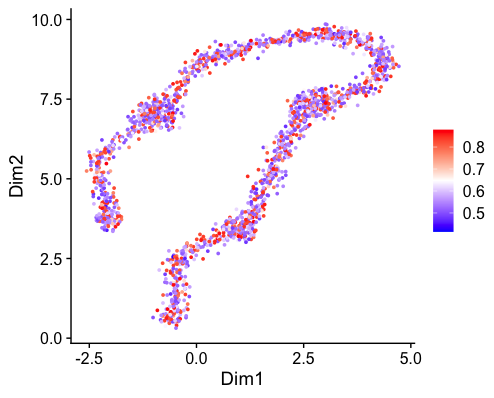

```r
sim.daseq$pred.plot
```

This plot shows what `DAseq` predicts as being as the DA cells, i.e. different between conditions A and B. By default the DA cells are selected in the top and bottom 5% of quantiles - I’ll keep this as it will select the best 10% overall.

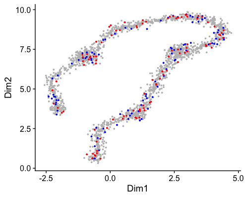

```r
sim.daseq$da.cells.plot
```

These top 10% of DA cells are specifically highlighted here. The DA regions are identified by grouping the coherently DA cells together by `DAseq`.

```r
sim.da_regions <- getDAregion(X=reducedDim(sim.mylo)[, 1:n.dim],
                              da.cells=sim.daseq,
                              min.cell=5,
                              cell.labels=sim.meta$cell_id,
                              labels.1=sim.meta$cell_id[sim.meta$Condition %in% c("A")],
                              labels.2=sim.meta$cell_id[sim.meta$Condition %in% c("B")],
                              size=1,
                              resolution=0.01, plot.embedding=as.matrix(sim.fr.df[, c("V1", "V2")]))
str(sim.da_regions[1:2])
```

```
List of 2
 $ da.region.label: num [1:2000] 0 1 0 0 0 0 0 3 0 0 ...
 $ DA.stat        : num [1:5, 1:3] 0.799 -0.421 -0.449 -0.224 -0.595 ...
  ..- attr(*, "dimnames")=List of 2
  .. ..$ : NULL
  .. ..$ : chr [1:3] "DA.score" "pval.wilcoxon" "pval.ttest"
```

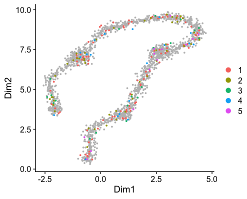

```r
sim.da_regions$da.region.plot
```

# Clustering - Louvain & Walktrap

```r
walktrap.clust <- cluster_walktrap(sim.graph, steps=3, membership=TRUE)
walktrap.clust.ids <- membership(walktrap.clust)
louvain.clust <- cluster_louvain(sim.graph)
louvain.clust.ids <- membership(louvain.clust)
sim.clust.df <- data.frame("cell_id"=colnames(sim.mylo), "Walktrap.Clust"=as.character(walktrap.clust.ids),
                           "Louvain.Clust"=as.character(louvain.clust.ids))
sim.clust.merge <- merge(sim.fr.df, sim.clust.df, by='cell_id')
sim.clust.merge$Sample <- paste(sim.fr.df$Condition, sim.fr.df$Replicate, sep="_")
```

## Louvain

```r
louvain.model <- model.matrix(~Condition, data=test.meta)
louvain.count <- as.matrix(table(sim.clust.merge$Louvain.Clust, sim.clust.merge$Sample))
louvain.dge <- DGEList(counts=louvain.count, lib.size=log(colSums(louvain.count)))
louvain.dge <- estimateDisp(louvain.dge, louvain.model)
louvain.fit <- glmQLFit(louvain.dge, louvain.model, robust=TRUE)
louvain.res <- as.data.frame(topTags(glmQLFTest(louvain.fit, coef=2), sort.by='none', n=Inf))
table(louvain.res$FDR <= 0.1)
```

```
FALSE  TRUE
    5     4
```

## Walktrap

```r
walktrap.model <- model.matrix(~Condition, data=test.meta)
walktrap.count <- as.matrix(table(sim.clust.merge$Walktrap.Clust, sim.clust.merge$Sample))
walktrap.dge <- DGEList(counts=walktrap.count, lib.size=log(colSums(walktrap.count)))
walktrap.dge <- estimateDisp(walktrap.dge, walktrap.model)
walktrap.fit <- glmQLFit(walktrap.dge, walktrap.model, robust=TRUE)
walktrap.res <- as.data.frame(topTags(glmQLFTest(walktrap.fit, coef=2), sort.by='none', n=Inf))
table(walktrap.res$FDR <= 0.1)
```

```
FALSE  TRUE
    7     4
```

# Comparing methods

As stated above, I will assess the performance of each methods by calculating the ratio of cells that *should* be DA against those that are DA but *should not be*.

```r
true.da.cells <- sim.meta$cell_id[sim.meta$group_id %in% "M3"]
milo.da.cells <- unique(sim.meta$cell_id[unique(unlist(nhoods(sim.mylo)[mylo.res$Nhood[mylo.res$Diff != 0]]))])
cydar.da.cells <- sim.meta$cell_id[unique(unlist(cellAssignments(sim.cydar)[as.numeric(rownames(cydar.res)[cydar.res$SpatialFDR <= 0.1])]))]
louvain.da.cells <- sim.clust.merge$cell_id[sim.clust.merge$Louvain.Clust %in% rownames(louvain.res)[louvain.res$FDR <= 0.1]]
walktrap.da.cells <- sim.clust.merge$cell_id[sim.clust.merge$Walktrap.Clust %in% rownames(walktrap.res)[walktrap.res$FDR <= 0.1]]
daseq.da.cells <- sim.meta$cell_id[sim.da_regions$da.region.label != 0]
da.cell.df <- data.frame("Method"=c("Truth", "Milo", "Cydar", "Louvain", "Walktrap", "DAseq"),
                         "NCells"=c(length(true.da.cells), length(milo.da.cells), length(cydar.da.cells),
                                    length(louvain.da.cells), length(walktrap.da.cells), length(daseq.da.cells)))
```

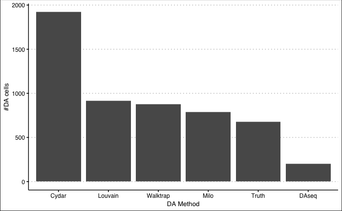

```r
ggplot(da.cell.df, aes(x=reorder(Method, -NCells), y=NCells)) +
    geom_bar(stat='identity') +
    theme_clean() +
    labs(x="DA Method", y="#DA cells")
```

```r
# calculate true DA cells
true.neg <- factor(sim.meta$cell_id %in% true.da.cells, levels=c(FALSE, TRUE))
milo.neg <- factor(sim.meta$cell_id %in% milo.da.cells, levels=c(FALSE, TRUE))
cydar.neg <- factor(sim.meta$cell_id %in% cydar.da.cells, levels=c(FALSE, TRUE))
louvain.neg <- factor(sim.meta$cell_id %in% louvain.da.cells, levels=c(FALSE, TRUE))
walktrap.neg <- factor(sim.meta$cell_id %in% walktrap.da.cells, levels=c(FALSE, TRUE))
daseq.neg <- factor(sim.meta$cell_id %in% daseq.da.cells, levels=c(FALSE, TRUE))
milo.confuse <- table(true.neg, milo.neg)
cydar.confuse <- table(true.neg, cydar.neg)
louvain.confuse <- table(true.neg, louvain.neg)
walktrap.confuse <- table(true.neg, walktrap.neg)
daseq.confuse <- table(true.neg, daseq.neg)
milo.confuse.list <- list("TP"=milo.confuse[2, 2], "FP"=milo.confuse[1, 2], "TN"=milo.confuse[1, 1], "FN"=milo.confuse[2, 1])
cydar.confuse.list <- list("TP"=cydar.confuse[2, 2], "FP"=cydar.confuse[1, 2], "TN"=cydar.confuse[1, 1], "FN"=cydar.confuse[2, 1])
louvain.confuse.list <- list("TP"=louvain.confuse[2, 2], "FP"=louvain.confuse[1, 2], "TN"=louvain.confuse[1, 1], "FN"=louvain.confuse[2, 1])
walktrap.confuse.list <- list("TP"=walktrap.confuse[2, 2], "FP"=walktrap.confuse[1, 2], "TN"=walktrap.confuse[1, 1], "FN"=walktrap.confuse[2, 1])
daseq.confuse.list <- list("TP"=daseq.confuse[2, 2], "FP"=daseq.confuse[1, 2], "TN"=daseq.confuse[1, 1], "FN"=daseq.confuse[2, 1])
```

```r
milo.ppv <- milo.confuse.list$TP/(milo.confuse.list$TP + milo.confuse.list$FP)
cydar.ppv <- cydar.confuse.list$TP/(cydar.confuse.list$TP + cydar.confuse.list$FP)
louvain.ppv <- louvain.confuse.list$TP/(louvain.confuse.list$TP + louvain.confuse.list$FP)
walktrap.ppv <- walktrap.confuse.list$TP/(walktrap.confuse.list$TP + walktrap.confuse.list$FP)
daseq.ppv <- daseq.confuse.list$TP/(daseq.confuse.list$TP + daseq.confuse.list$FP)
milo.fdr <- milo.confuse.list$FP/(milo.confuse.list$TP + milo.confuse.list$FP)
cydar.fdr <- cydar.confuse.list$FP/(cydar.confuse.list$TP + cydar.confuse.list$FP)
louvain.fdr <- louvain.confuse.list$FP/(louvain.confuse.list$TP + louvain.confuse.list$FP)
walktrap.fdr <- walktrap.confuse.list$FP/(walktrap.confuse.list$TP + walktrap.confuse.list$FP)
daseq.fdr <- daseq.confuse.list$FP/(daseq.confuse.list$TP + daseq.confuse.list$FP)
milo.fnr <- milo.confuse.list$FN/(milo.confuse.list$TP + milo.confuse.list$FN)
cydar.fnr <- cydar.confuse.list$FN/(cydar.confuse.list$TP + cydar.confuse.list$FN)
louvain.fnr <- louvain.confuse.list$FN/(louvain.confuse.list$TP + louvain.confuse.list$FN)
walktrap.fnr <- walktrap.confuse.list$FN/(walktrap.confuse.list$TP + walktrap.confuse.list$FN)
daseq.fnr <- daseq.confuse.list$FN/(daseq.confuse.list$TP + daseq.confuse.list$FN)
milo.fpr <- milo.confuse.list$FP/(milo.confuse.list$FP + milo.confuse.list$TN)
cydar.fpr <- cydar.confuse.list$FP/(cydar.confuse.list$FP + cydar.confuse.list$TN)
louvain.fpr <- louvain.confuse.list$FP/(louvain.confuse.list$FP + louvain.confuse.list$TN)
walktrap.fpr <- walktrap.confuse.list$FP/(walktrap.confuse.list$FP + walktrap.confuse.list$TN)
daseq.fpr <- daseq.confuse.list$FP/(daseq.confuse.list$FP + daseq.confuse.list$TN)
milo.for <- milo.confuse.list$FN/(milo.confuse.list$FN + milo.confuse.list$TN)
cydar.for <- cydar.confuse.list$FN/(cydar.confuse.list$FN + cydar.confuse.list$TN)
louvain.for <- louvain.confuse.list$FN/(louvain.confuse.list$FN + louvain.confuse.list$TN)
walktrap.for <- walktrap.confuse.list$FN/(walktrap.confuse.list$FN + walktrap.confuse.list$TN)
daseq.for <- daseq.confuse.list$FN/(daseq.confuse.list$FN + daseq.confuse.list$TN)
milo.tpr <- milo.confuse.list$TP/(milo.confuse.list$TP + milo.confuse.list$FN)
cydar.tpr <- cydar.confuse.list$TP/(cydar.confuse.list$TP + cydar.confuse.list$FN)
louvain.tpr <- louvain.confuse.list$TP/(louvain.confuse.list$TP + louvain.confuse.list$FN)
walktrap.tpr <- walktrap.confuse.list$TP/(walktrap.confuse.list$TP + walktrap.confuse.list$FN)
daseq.tpr <- daseq.confuse.list$TP/(daseq.confuse.list$TP + daseq.confuse.list$FN)
milo.tnr <- milo.confuse.list$TN/(milo.confuse.list$TN + milo.confuse.list$FP)
cydar.tnr <- cydar.confuse.list$TN/(cydar.confuse.list$TN + cydar.confuse.list$FP)
louvain.tnr <- louvain.confuse.list$TN/(louvain.confuse.list$TN + louvain.confuse.list$FP)
walktrap.tnr <- walktrap.confuse.list$TN/(walktrap.confuse.list$TN + walktrap.confuse.list$FP)
daseq.tnr <- daseq.confuse.list$TN/(daseq.confuse.list$TN + daseq.confuse.list$FP)
milo.npv <- milo.confuse.list$TN/(milo.confuse.list$TN + milo.confuse.list$FN)
cydar.npv <- cydar.confuse.list$TN/(cydar.confuse.list$TN + cydar.confuse.list$FN)
louvain.npv <- louvain.confuse.list$TN/(louvain.confuse.list$TN + louvain.confuse.list$FN)
walktrap.npv <- walktrap.confuse.list$TN/(walktrap.confuse.list$TN + walktrap.confuse.list$FN)
daseq.npv <- daseq.confuse.list$TN/(daseq.confuse.list$TN + daseq.confuse.list$FN)
da.fdr.df <- data.frame("Method"=c("Milo", "Cydar", "Louvain", "Walktrap", "DAseq"),
                        "PPV"=c(milo.ppv, cydar.ppv, louvain.ppv, walktrap.ppv, daseq.ppv),
                        "NPV"=c(milo.npv, cydar.npv, louvain.npv, walktrap.npv, daseq.npv),
                        "FDR"=c(milo.fdr, cydar.fdr, louvain.fdr, walktrap.fdr, daseq.fdr),
                        "FPR"=c(milo.fpr, cydar.fpr, louvain.fpr, walktrap.fpr, daseq.fpr),
                        "FNR"=c(milo.fnr, cydar.fnr, louvain.fnr, walktrap.fnr, daseq.fnr),
                        "FOR"=c(milo.for, cydar.for, louvain.for, walktrap.for, daseq.for),
                        "TPR"=c(milo.tpr, cydar.tpr, louvain.tpr, walktrap.tpr, daseq.tpr),
                        "TNR"=c(milo.tnr, cydar.tnr, louvain.tnr, walktrap.tnr, daseq.tnr))
da.fdr.df$MCC <- sqrt(da.fdr.df$PPV * da.fdr.df$TPR * da.fdr.df$TNR * da.fdr.df$NPV) -
    sqrt(da.fdr.df$FDR * da.fdr.df$FNR * da.fdr.df$FPR * da.fdr.df$FOR)
da.fdr.df$F1 <- 2*((da.fdr.df$PPV * da.fdr.df$TPR)/(da.fdr.df$PPV + da.fdr.df$TPR))
da.fdr.df$Power <- 1 - da.fdr.df$FNR
```

I’ve compute the confusion matrix for each method, from which I have calculated the precision (positive predictive value), recall (TPR), FDR and Matthews correlation coefficient (MCC).

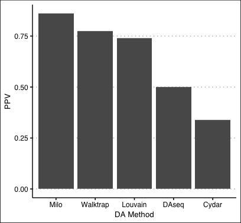

```r
ggplot(da.fdr.df, aes(x=reorder(Method, -PPV), y=PPV)) +
    geom_bar(stat='identity') +
    theme_clean() +
    labs(x="DA Method", y="PPV")
```

```r
ggsave("~/Dropbox/Milo/figures/MethodCompare_PPV.pdf",
       height=3.95, width=4.25, useDingbats=FALSE)
```

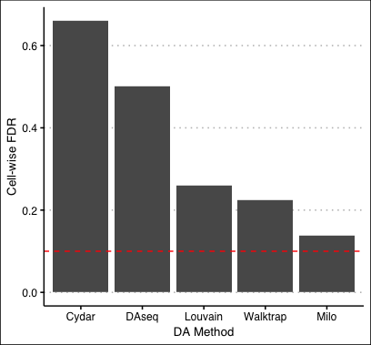

```r
ggplot(da.fdr.df, aes(x=reorder(Method, -FDR), y=FDR)) +
    geom_bar(stat='identity') +
    geom_hline(yintercept=0.1, lty=2, col='red') +
    theme_clean() +
    labs(x="DA Method", y="Cell-wise FDR")
```

```r
ggsave("~/Dropbox/Milo/figures/MethodCompare_FDR.pdf",
       height=3.95, width=4.25, useDingbats=FALSE)
```

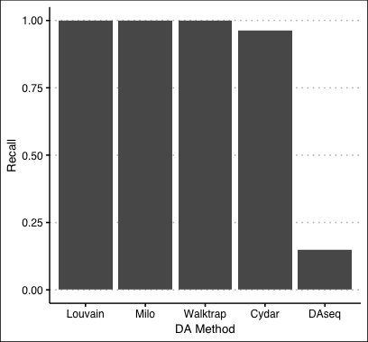

```r
ggplot(da.fdr.df, aes(x=reorder(Method, -TPR), y=TPR)) +
    geom_bar(stat='identity') +
    theme_clean() +
    labs(x="DA Method", y="Recall")
```

```r
ggsave("~/Dropbox/Milo/figures/MethodCompare_Recall.pdf",
       height=3.95, width=4.25, useDingbats=FALSE)
```

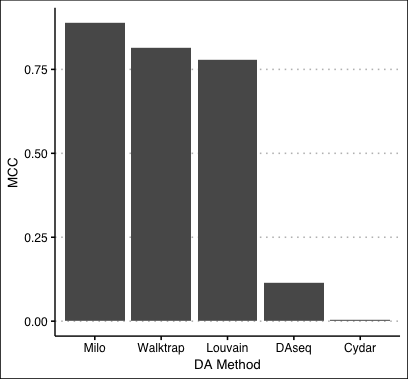

```r
ggplot(da.fdr.df, aes(x=reorder(Method, -MCC), y=MCC)) +
    geom_bar(stat='identity') +
    theme_clean() +
    labs(x="DA Method", y="MCC")
```

```r
ggsave("~/Dropbox/Milo/figures/MethodCompare_MCC.pdf",
       height=3.95, width=4.25, useDingbats=FALSE)
```

What does the power look like?

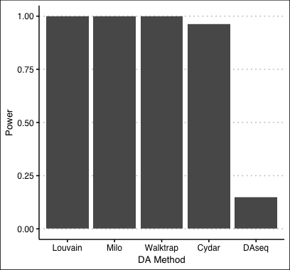

```r
ggplot(da.fdr.df, aes(x=reorder(Method, -Power), y=Power)) +
    geom_bar(stat='identity') +
    theme_clean() +
    labs(x="DA Method", y="Power")
```

```r
ggsave("~/Dropbox/Milo/figures/MethodCompare_Power.pdf",
       height=3.95, width=4.25, useDingbats=FALSE)
```